# Lab 5 - Ensemble methods - boosting

## Name and id:

## About the data

### Context

News article datasets, originating from BBC News, provided for use as benchmarks for machine learning research. The original data is processed to form a single csv file for ease of use, the news title and the related text file name is preserved along with the news content and its category. This dataset is made available for non-commercial and research purposes only.

All rights, including copyright, in the content of the original articles are owned by the BBC.

### Content

Consists of 2225 documents from the BBC news website corresponding to stories in five topical areas from 2004-2005. Class Labels: 5 (business, entertainment, politics, sport, tech)

### Acknowledgements

It might be interesting to read the associated [research article](http://mlg.ucd.ie/files/publications/greene06icml.pdf).

#### Associated Official Research Papers

D. Greene and P. Cunningham. "Practical Solutions to the Problem of Diagonal Dominance in Kernel Document Clustering", Proc. ICML 2006.

using 'kaggle.json' file from the first lab, load the competition's data:

(remember to upload it to your environment)

You suppose to have 3 files:

```
newsgroup20bbcnews.zip
```

```python
! mkdir ~/.kaggle
! cp kaggle.json ~/.kaggle/
! chmod 600 ~/.kaggle/kaggle.json
! kaggle datasets download balatmak/newsgroup20bbcnews
! unzip newsgroup20bbcnews.zip
```

```
Downloading newsgroup20bbcnews.zip to /content
 66% 10.0M/15.1M [00:00<00:00, 104MB/s]
100% 15.1M/15.1M [00:00<00:00, 129MB/s]
Archive:  newsgroup20bbcnews.zip
  inflating: bbc-text.csv
  inflating: news_group20.csv
```

```python
import pandas as pd

data = pd.read_csv('/content/bbc-text.csv')
data.head(10)
```

|  | category | text |
| --- | --- | --- |
| 0 | tech | tv future in the hands of viewers with home th... |
| 1 | business | worldcom boss left books alone former worldc... |
| 2 | sport | tigers wary of farrell gamble leicester say ... |
| 3 | sport | yeading face newcastle in fa cup premiership s... |
| 4 | entertainment | ocean s twelve raids box office ocean s twelve... |
| 5 | politics | howard hits back at mongrel jibe michael howar... |
| 6 | politics | blair prepares to name poll date tony blair is... |
| 7 | sport | henman hopes ended in dubai third seed tim hen... |
| 8 | sport | wilkinson fit to face edinburgh england captai... |
| 9 | entertainment | last star wars not for children the sixth an... |

## Task 1:

Load 'bbc-text.csv' file. As you can see, this time we are working with textual data.

To use it for calssification models we should tokenize it and create features out of the text.

Use sklearn.feature_extraction.text.TfidfVectorizer with stop_words='english', max_features=1000 and analyzer='word' to convert the text into features.

Use sklearn.preprocessing.LabelEncoder to encode the category

Split the data into train and test with 25% test

```python
from sklearn.feature_extraction.text import TfidfVectorizer
from sklearn import preprocessing
from sklearn.model_selection import train_test_split
```

```python
# implemet here
le = preprocessing.LabelEncoder()
le.fit(data["category"])
le.classes_
category = le.transform(data["category"])
```

```python
category
```

```
array([4, 0, 3, ..., 1, 2, 3])
```

```python
vectorizer = TfidfVectorizer(stop_words='english', max_features=1000, analyzer='word')
text_transformed = vectorizer.fit_transform(data["text"])
# vectorizer.get_feature_names_out()
text_tfidf = text_transformed.toarray()
```

```python
text_tfidf
```

```
array([[0.0297058 , 0.        , 0.04239449, ..., 0.        , 0.        ,
        0.        ],
       [0.05979859, 0.        , 0.        , ..., 0.        , 0.        ,
        0.        ],
       [0.        , 0.        , 0.        , ..., 0.        , 0.        ,
        0.        ],
       ...,
       [0.05798066, 0.12169008, 0.        , ..., 0.        , 0.        ,
        0.        ],
       [0.0395347 , 0.        , 0.        , ..., 0.        , 0.        ,
        0.        ],
       [0.        , 0.        , 0.        , ..., 0.        , 0.        ,
        0.        ]])
```

```python
X_train, X_test, y_train, y_test = train_test_split(
    text_tfidf, category, test_size=0.25, random_state=300)
```

## Task 2:

Create and train each of the following:

- sklearn.ensemble.AdaBoostClassifier with DecisionTreeClassifier
- XGBoost.XGBClassifier
- logitboost.LogitBoost

with n_estimators=50, max_depth=5 and any other parameters you see fit.

```python
!pip install logitboost
```

```python
# implemet here
# adaboost and treeclassifier
from sklearn.ensemble import AdaBoostClassifier
from sklearn.tree import DecisionTreeClassifier
model1 = AdaBoostClassifier(n_estimators=50, random_state=300, base_estimator= DecisionTreeClassifier(max_depth=5))
model1.fit(X_train, y_train)
model_1_pred = model1.predict(X_test)
```

```python
from sklearn.metrics import accuracy_score
print("model 1:", accuracy_score(y_test, model_1_pred))
```

```
model 1: 0.9210053859964094
```

```python
# xgboost
import xgboost as xgb
model2= xgb.XGBClassifier(n_estimators=50, random_state=300, max_depth=5)
model2.fit(X_train,y_train)
model_2_pred = model2.predict(X_test)
```

```python
print("model 2:", accuracy_score(y_test, model_2_pred))
```

```
model 2: 0.9569120287253142
```

## Task 3:

Test and evaluate each of the models using accuracy score

```python
# implemet here
# logitboost
import logitboost
from sklearn.tree import DecisionTreeRegressor

model3 = logitboost.LogitBoost(n_estimators=50, random_state=300, base_estimator= DecisionTreeRegressor(max_depth=5))
model3.fit(X_train,y_train)
model_3_pred = model3.predict(X_test)
```

```python
print("model 3:", accuracy_score(y_test, model_3_pred))
```

```
model 3: 0.9605026929982047
```

## Task 4:

LogitBoost reveals good performances, run the following code to create a plot of the model's accuracy for each boosting stage.

What can you say about the model performances? What would you change?

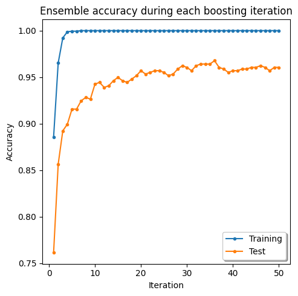

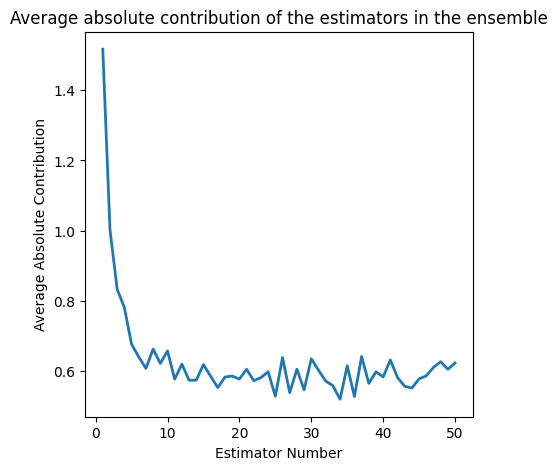

```python
import numpy as np
import matplotlib.pyplot as plt


iterations = np.arange(1, model3.n_estimators + 1)
staged_accuracy_train = list(model3.staged_score(X_train, y_train))
staged_accuracy_test = list(model3.staged_score(X_test, y_test))

plt.figure(figsize=(5, 5))
plt.plot(iterations, staged_accuracy_train, label='Training', marker='.')
plt.plot(iterations, staged_accuracy_test, label='Test', marker='.')

plt.xlabel('Iteration')
plt.ylabel('Accuracy')
plt.title('Ensemble accuracy during each boosting iteration')
plt.legend(loc='best', shadow=True, frameon=True)

plt.tight_layout()
plt.show()

plt.figure(figsize=(5, 5))
plt.plot(iterations, model3.contributions(X_train), lw=2)
plt.xlabel('Estimator Number')
plt.ylabel('Average Absolute Contribution')
plt.title('Average absolute contribution of the estimators in the ensemble')
plt.show()
plt.close()
```

Answer Here - The model is look good with a good accuracy

## Task 5:

Convert the notebook into html:

1. Download the notebook by clicking the File tab
2. Upload it to this environment
3. Run the command:

```python
%%shell
jupyter nbconvert --to html Lab5.ipynb
```